# WeibullR.plotly: Interactive Weibull Probability Plots

11 July 2024

## Statement of Need

Life data analysis examines the behavior of systems over time. Often termed Weibull data analysis, due to the common use of the Weibull distribution, this field involves iterative data wrangling, modeling, and visualization. Interactive Weibull modeling offers numerous advantages, such as the ability to explore subsamples and uncover hidden data structures. `WeibullR.plotly` (Govan 2023b) is an open-source software package designed for creating interactive Weibull Probability Plots. It aims to provide more flexibility for exploratory Weibull analysis than traditional static plotting. The primary users of this project are reliability engineers and university students specializing in reliability engineering.

## Description

`WeibullR.plotly` is developed in R (R Core Team 2023), leveraging `WeibullR` (Silkworth and Symynck 2022), a package dedicated to Life Data Analysis, and `plotly` (Sievert 2020), an interactive web-based graphing library.

### Usage

#### Weibull Probability Plots

Fit a `wblr` object to a life data set using the `WeibullR` package, then generate plots with the `plotly_wblr` function.

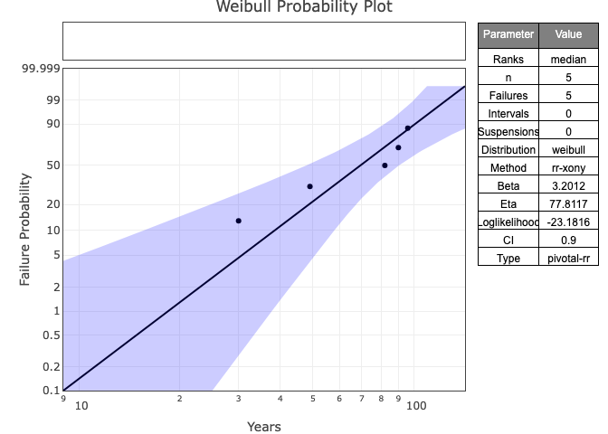

```r
plotly_wblr(obj, main='Weibull Probability Plot', xlab='Years', ylab='Failure Probability', confCol='blue', signif=4, grid=FALSE)
```

#### Contour Plots

Create contour plots using the `plotly_contour` function with a `wblr` object.

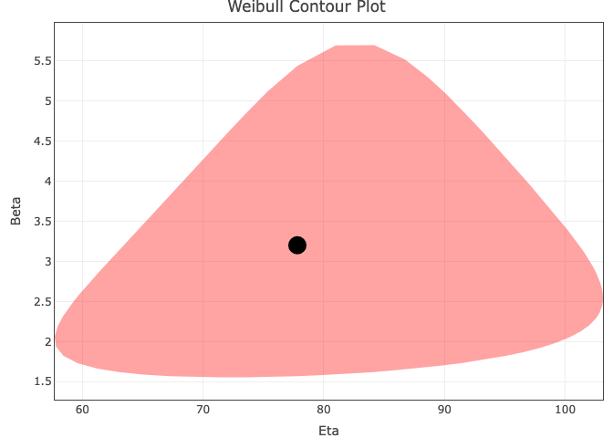

```r
plotly_contour(obj, main='Weibull Contour Plot', col='red', signif=4, grid=FALSE)
```

#### Customization Options

Customize labels, colors, and grids to tailor the plots to specific needs. Refer to the package documentation for a comprehensive list of options.

### Documentation and Resources

The project documentation provides:

- **Installation Instructions**: Guidance on installing `WeibullR.plotly` and its dependencies.
- **Function Examples**: Demonstrations of how to use the package functions.
- **Unit Tests**: Ensuring code reliability and performance.
- **Further Learning Resources**:
  - `WeibullR.learnr` (Govan 2023a): An interactive introduction to Life Data Analysis.
  - `WeibullR.shiny` (Govan 2023c): A shiny (Chang et al. 2024) web application for Life Data Analysis that leverages `WeibullR.plotly`.

### Contribution and Community Engagement

Engineers and analysts are encouraged to use and contribute to the project. The repository includes a Contributor Code of Conduct. Issues and feature requests can be submitted through Issues or Pull Requests.

## References

Chang, Winston, Joe Cheng, JJ Allaire, Carson Sievert, Barret Schloerke, Yihui Xie, Jeff Allen, Jonathan McPherson, Alan Dipert, and Barbara Borges. 2024. *Shiny: Web Application Framework for r*. https://CRAN.R-project.org/package=shiny.

Govan, Paul. 2023a. *WeibullR.learnr: An Interactive Introduction to Life Data Analysis*. https://paulgovan.github.io/WeibullR.learnr/.

———. 2023b. *WeibullR.plotly: Interactive Weibull Probability Plots with ’WeibullR’*. https://CRAN.R-project.org/package=WeibullR.plotly.

———. 2023c. *WeibullR.shiny: A ’Shiny’ App for Weibull Analysis from ’WeibullR’*. https://paulgovan.github.io/WeibullR.shiny/.

R Core Team. 2023. *R: A Language and Environment for Statistical Computing*. Vienna, Austria: R Foundation for Statistical Computing. https://www.R-project.org/.

Sievert, Carson. 2020. *Interactive Web-Based Data Visualization with r, Plotly, and Shiny*. Chapman; Hall/CRC. https://plotly-r.com.

Silkworth, David, and Jurgen Symynck. 2022. *WeibullR: Weibull Analysis for Reliability Engineering*. https://CRAN.R-project.org/package=WeibullR.